# Assignment 4

Michael Culshaw-Maurer

2/2/2017

First let’s put in some stuff we’ll use the whole time:

```r
disp <- function(y,x){exp(-abs(y-m-x)/a)/(2*a)} # function for the dispersal kernel
# values for the dispersal kernel and growth
a <- 2
m <- 1
R <- 4

K <- function(y,x)R*disp(y,x) # here's our final kernel

n <- 200 # always going to use a length of 200 for discretization, just to be consistent
```

Now for Question 1:

Create a function to generate a matrix from an L value:

```r
M <- function(L){
deltax <- (L--L)/n # defining delta x based on the length L and n
xs <- seq(-L+deltax/2,L-deltax/2,length=n) # create xs using midpoints
A <- outer(xs,xs,K)*deltax # calculate the projection matrix for the given L value and discretization
return(A)
}
```

Create the matrix for an L value of 10

```r
L <- 10
A <- M(L)
```

Now, we’ll use the projection matrix to iterate the population forward in time, given a starting distribution of a density of 1 between -2 and 2.

The population vectors need to be the same length as a row or column in the matrix, and then we need to figure out which entries in the starting vector should be 1 and which should be 0. This means we need to know the entries in our xs sequence, then figure out which ones are between -2 and 2. Since it’s hard to figure this out in your head, I think it’s easier to just generate the xs sequence (outside the function) and create a starting sequence based off of this.

```r
deltax <- (L--L)/n # making our delta x for L=10
xs <- seq(-L+deltax/2,L-deltax/2,length=n) # xs for L=10
starting <- rep(NA,length(xs)) # create a starting N(1,x)

# now just populate the starting vector with 1s between -2 and 2, and 0s elsewhere
starting[which(xs <= 2)] <- 1
starting[which(xs > 2)] <- 0
starting[which(xs < -2)] <- 0

results <- matrix(NA,nrow=5,ncol = length(xs)) # a matrix to hold our results, a distribution over 5 time steps
results[1,] <- starting # the first time step is our starting population distribution

# now we generate the rest of the time steps, 2 to 5, projected from our starting distribution
for(i in 2:5){
  results[i,] <- A%*%results[i-1,]
}
```

Plot it out:

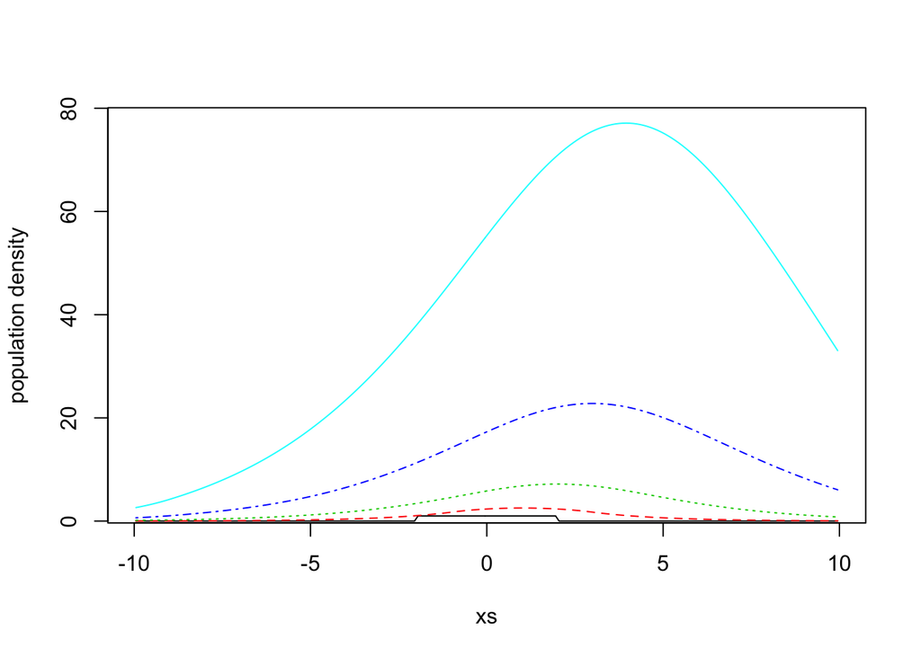

```r
plot(xs,results[5,],type="l",col=5,ylab="population density") # first plot the largest result
for(l in 1:4){ # now plot the rest
  lines(xs,results[l,],lty=l,col=l)
}
```

Now for Question 2:

```r
L.seq <- seq(from=0,to=5,length=100) # create sequence of L values
dom.eig <- rep(NA,length(L.seq)) # create a blank vector to hold the eigenvalues

for(q in 1:length(L.seq)){ # for each value in the L sequence
  dom.eig[q] <- Re(eigen(M(L.seq[q]))$values[1]) # use the M function to generate a matrix from a value in the L sequence, then calculate the leading eigenvalue of it
}
```

Plot it up:

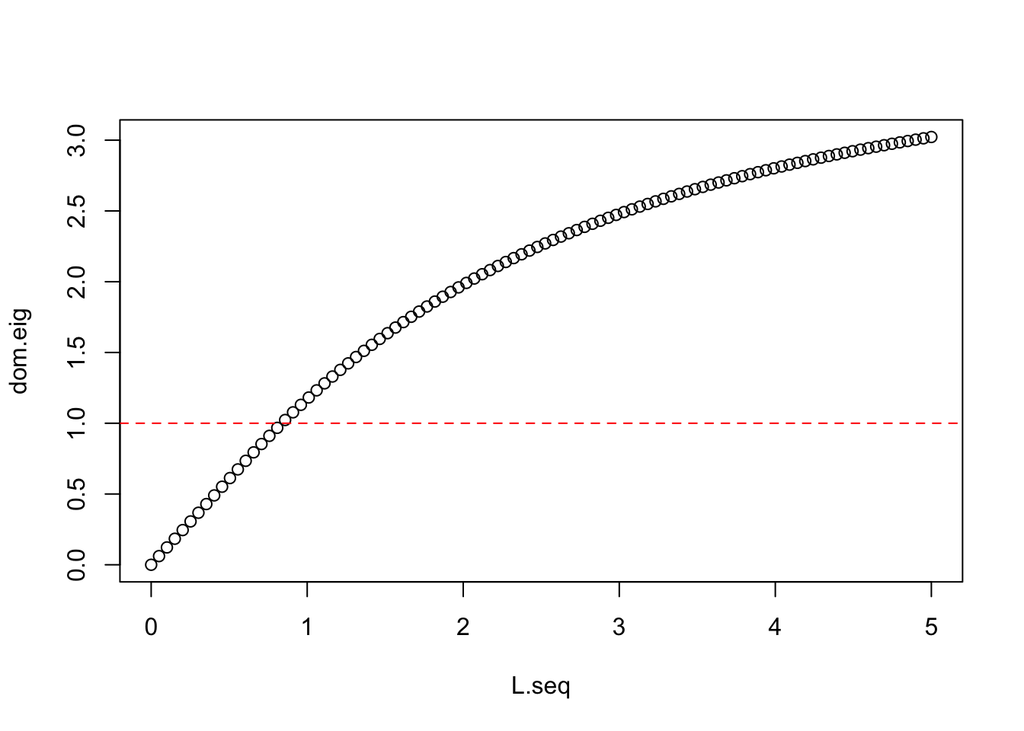

```r
plot(L.seq,dom.eig) # plot the dominant eigenvalues against the sequence of L values
abline(h=1,lty=2,col="red") # add a horizontal line at an eigenvalue of 1
```